# The Statistical Dangers of Between-Species Comparisons

Jake L. Weissman

July 4, 2020

**Disclaimer:** This is intended to be a short introduction to the idea of phylogenetically structured data. My main goal is to make sure you know that you have to be careful when doing statistics on species data. If you want an introduction to phylogenetic comparative methods (a rich subfield of evolutionary biology) I recommend starting with [Luke Harmon’s free online textbook](https://lukejharmon.github.io/pcm/) or any of [many other texts on the topic](https://link.springer.com/book/10.1007%2F978-3-662-43550-2) (or [workshop notes online](http://lukejharmon.github.io/ilhabela/) or [here](http://www.phytools.org/Cordoba2017/)).

## Comparative Data

This lesson is focused on how to deal with “phylogenetically structured” data. For example, imagine that we have some trait data for a set of species of bacteria, perhaps about mean cell size and minimum generation time. It is often supposed that larger cells are associated with rapid maximal growth rates. It seems that it would be a simple matter to test this association - one could simply calulate the correlation between the two variables. In fact, if you proceed without caution you run the risk of obtaining a significant, but spurious statistical result.

Some other examples of research questions involving phylogenetically structured data:  
- trying to associate pathogenicity with other traits (e.g., genome size)  
- trying to associate the traits of different species with different habitat types (e.g., do beige things live in the desert and dark green things in the forst)

The problem is that most (simple) statistical tests (parametric and non-parametric) assume independent datapoints, and your data is anything but. Consider that the species in your dataset share an evolutionary history, leading their traits to share a hierarchical dependency structure. Any time you are making comparisons between sets of species, you need to account for phylogenetic structure. [Felsenstein (1985)](https://www.jstor.org/stable/2461605) was the [first to really articulate the severity of this problem and provide an appropriate statistical treatment](https://doi.org/10.1086/703055) (the original linked “phylogenetic independent constrasts” paper is very clearly written and I highly recommend it).

I’m going to take you through this issue by generating some example phylogenetically-structured datasets in R and showing you how statistical tests can fail on these data.

I want to emphasize that I am not just being nitpicky - it is very easy to get spurious results with comparative data. There is a great paragraph near the end of the original Felsenstein paper:

*“Some reviewers of this paper felt that the message was”rather nihilistic," and* *suggested that it would be much improved if I could present a simple and robust* *method that obviated the need to have an accurate knowledge of the phylogeny. I* *entirely sympathize, but do not have a method that solves the problem. The best* *we can do is perhaps to use pairs of close relatives as suggested above, although* *this discards at least half of the data. Comparative biologists may understandably* *feel frustrated upon being told that they need to know the phylogenies of their* *groups in great detail, when this is not something they had much interest in* *knowing. Nevertheless, efforts to cope with the effects of the phylogeny will have* *to be made. Phylogenies are fundamental to comparative biology; there is no* *doing it without taking them into account." - [Felsenstein (1985)](https://www.jstor.org/stable/2461605)*

```r
if (!require("ggplot2")){
  install.packages("ggplot2")
  require("ggplot2")
}
if (!require("ape")){
  install.packages("ape")
  require("ape")
}
if (!require("phytools")){
  install.packages("phytools")
  require("phytools")
}
if (!require("picante")){
  install.packages("picante")
  require("picante")
}
if (!require("caper")){
  install.packages("caper")
  require("caper")
}
```

## Spurious Results With Phylogenetic Structure

Let’s start be generating some random data to work with. I am going to simulate the evolution of two traits on a phylogeny, and we are going to see how often those traits end up with correlated values **even though they will have no real association** (other than evolving on the same tree, that is).

First let’s make some phylogenies:

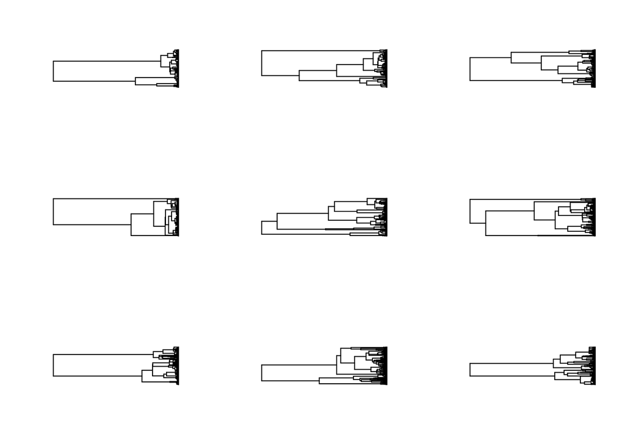

```r
# Generate 9 random phylogenies
n_trees <- 9
n_tips <- 1000
trees <- replicate(n_trees, rcoal(n_tips), simplify = FALSE)
par(mfrow=c(3,3))
for(i in 1:n_trees){
  plot.phylo(as.phylo(trees[[i]]), show.tip.label = FALSE)
}
```

```r
par(mfrow=c(1,1))
```

Now I am going to simulate the evolution of two traits on each of these phylogenies. We don’t need to get into it now, but I am using a simple [Brownian Motion](https://lukejharmon.github.io/pcm/chapter3_bmintro/) model of trait evolution that is pretty standard in the field. It results in normally-distributed changes in trait values along branches on the tree. Remember, I am going to let these traits evolve **independently** on the tree.

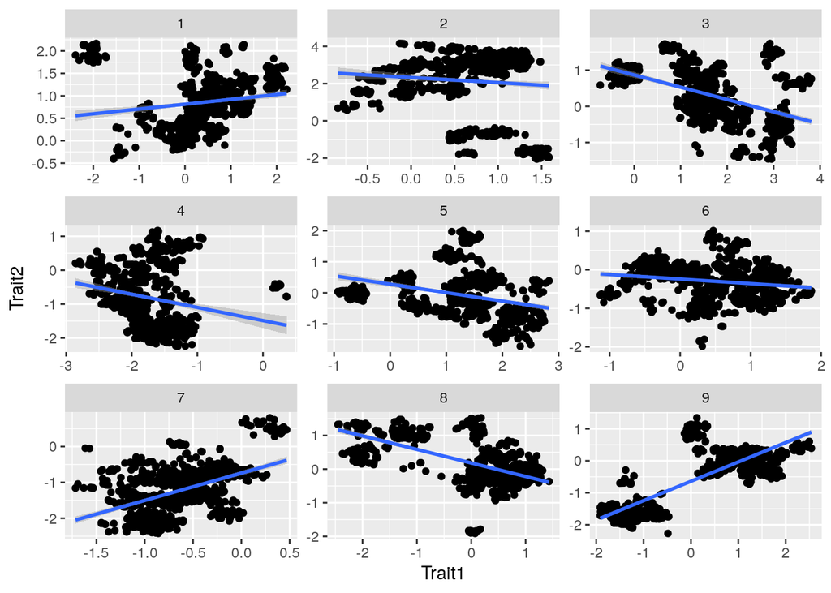

```r
# Randomly evolve two traits on these trees
trait_df <- data.frame(Trait1 = numeric(0),
                       Trait2 = numeric(0),
                       Tree = numeric(0))
for(i in 1:n_trees){
  trait_df <- rbind(trait_df,
                    data.frame(Trait1 = fastBM(trees[[i]]),
                               Trait2 = fastBM(trees[[i]]),
                               Tree = i))
}
ggplot(trait_df,aes(x = Trait1, y = Trait2)) +
  geom_point() +
  stat_smooth(method="lm") +
  facet_wrap(vars(Tree), scales = "free")
```

Wow, based on the confidence intervals those regression lines I’d say that at least a few of these simulated datasets have some pretty significant statistical relationships between our two traits (you can check this yourself if you really want to). But these traits don’t have any real relationship!

What if, instead, we let our traits evolve on a “star” shaped tree, where no hierarchical structure exists?

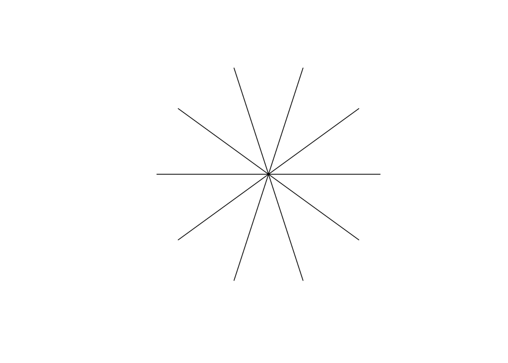

```r
n_tips <-  10 # reduce number of tips just for plotting
star <- starTree(1:n_tips, branch.lengths=rep(1,n_tips))
plot.phylo(star, type = "fan" , show.tip.label = FALSE)
```

We see a very different pattern in our traits:

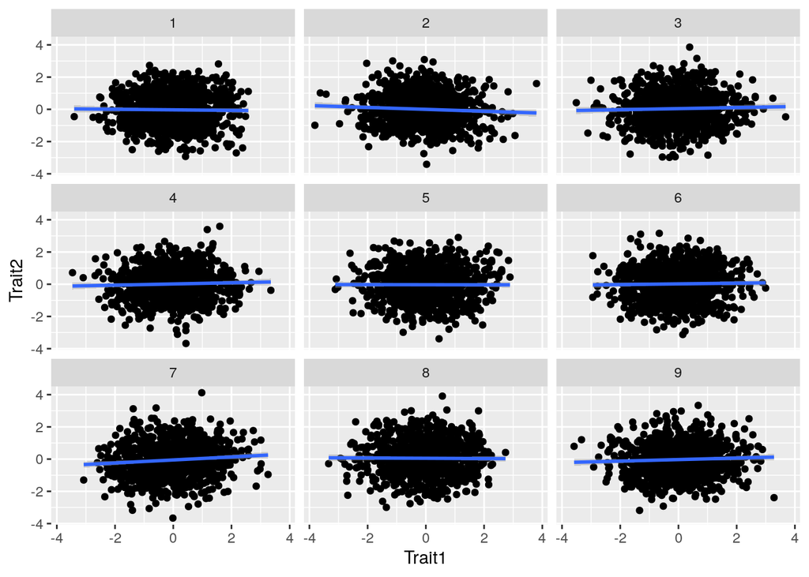

```r
# What if we simulated trait evolution on a star phylogeny instead?
n_tips <-  1000
star <- starTree(1:n_tips, branch.lengths=rep(1,n_tips))
star_df <- data.frame(Trait1 = numeric(0),
                       Trait2 = numeric(0),
                       Tree = numeric(0))
for(i in 1:n_trees){
  star_df <- rbind(star_df,
                    data.frame(Trait1 = fastBM(star),
                               Trait2 = fastBM(star),
                               Tree = i))
}
ggplot(star_df,aes(x = Trait1, y = Trait2)) +
  geom_point() +
  stat_smooth(method="lm") +
  facet_wrap(vars(Tree))
```

This time, because there is no phylogenetic structure, we don’t end up with a spurious result.

But why does phylogenetic structure lead us to a spurious result? There’s a few ways to conceptualize this but I’ve always found the easiest to be the idea of “pseudoreplication”. Pseudoreplication means you actually have fewer data points than you think you do.

It helps to imagine actual replication, where maybe you’ve accidentally duplicated your dataset, say 100 times.

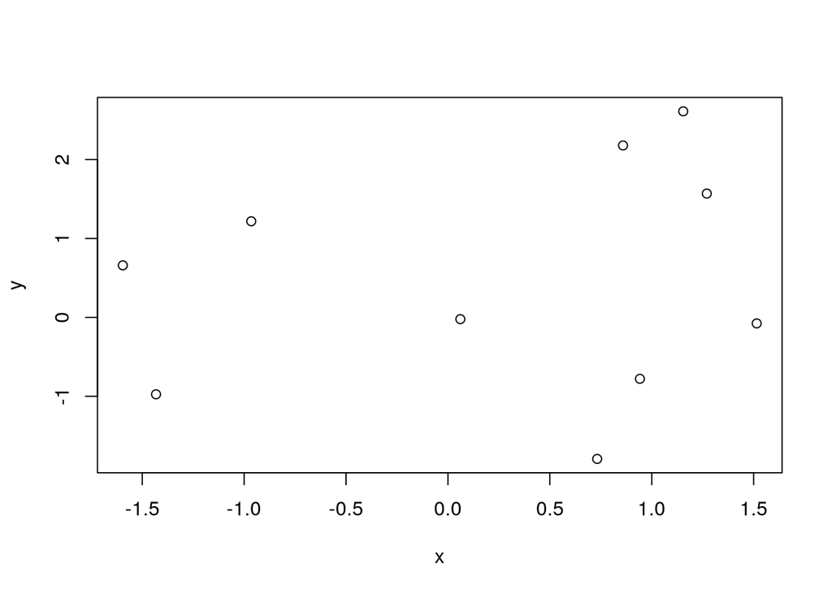

```r
x <- rnorm(10)
y <- rnorm(10)
plot(x,y)
```

```r
cor.test(x,y)
```

```
##
##  Pearson's product-moment correlation
##
## data:  x and y
## t = 0.51643, df = 8, p-value = 0.6195
## alternative hypothesis: true correlation is not equal to 0
## 95 percent confidence interval:
##  -0.5073919  0.7270225
## sample estimates:
##       cor
## 0.1796158
```

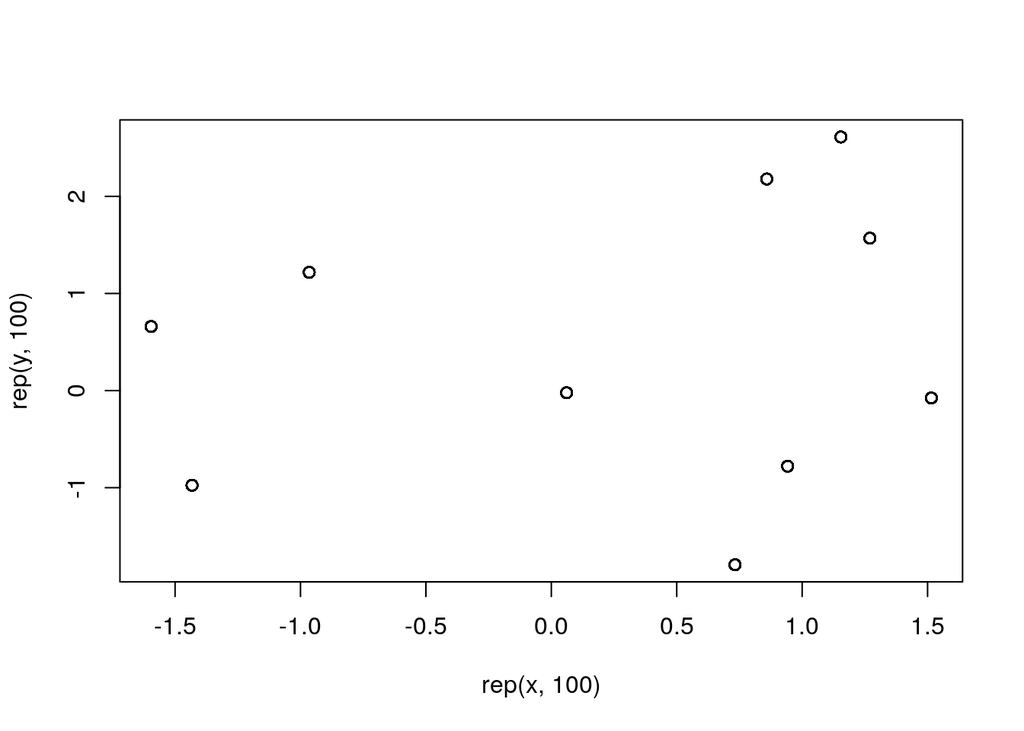

```r
plot(rep(x,100),rep(y,100))
```

```r
cor.test(rep(x,100),rep(y,100))
```

```
##
##  Pearson's product-moment correlation
##
## data:  rep(x, 100) and rep(y, 100)
## t = 5.7681, df = 998, p-value = 1.069e-08
## alternative hypothesis: true correlation is not equal to 0
## 95 percent confidence interval:
##  0.1189472 0.2389482
## sample estimates:
##       cor
## 0.1796158
```

By inflating the number of datapoints you have, you can force a significant result (see [Felsenstein (1985)](https://www.jstor.org/stable/2461605) for a discussion of this in terms of degrees of freedom - same idea).

When you draw from a phylogeny, you are essentially replicating pieces of evolutionary history (you are double counting the times where two species were actually the same ancestral species) - hence “pseudoreplication”. Changes in trait values that happened early on in evolutionary history get propagated to many ofspring, artificially inflating the importance of these changes.

It is easiest to see this when looking at a balanced tree with two very diverged groups.

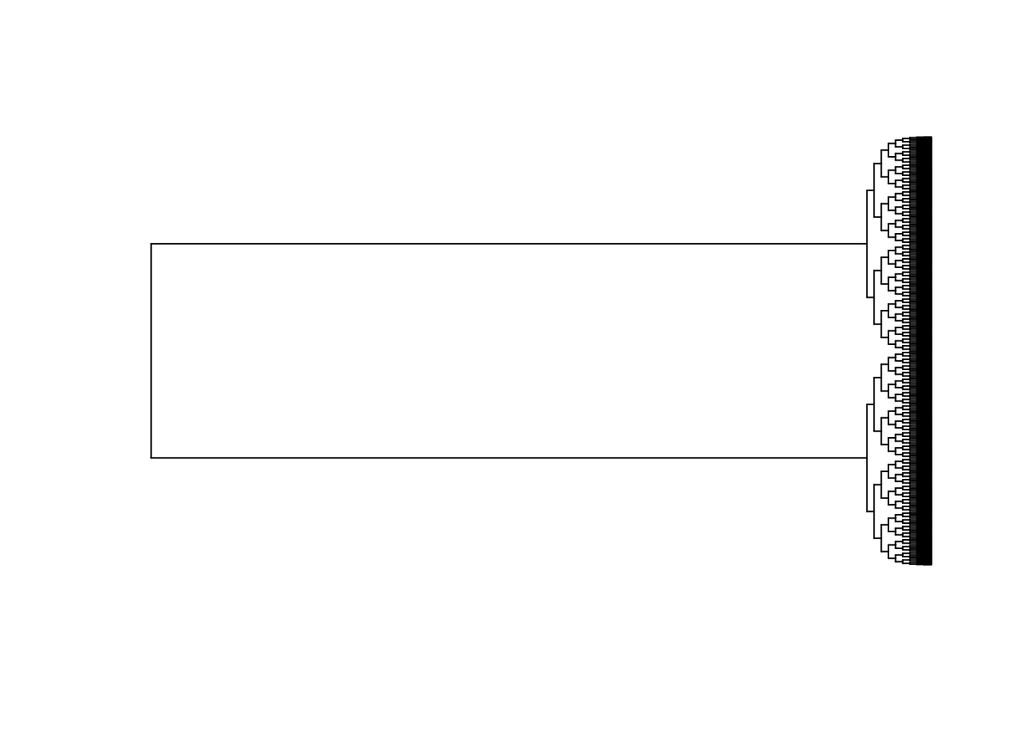

```r
n_tips <- 2^10
balanced <- stree(n_tips, type = "balanced", tip.label = NULL)
balanced$edge.length <- rep(1,nrow(balanced$edge))
balanced$edge.length[which(balanced$edge[,1]==1025)] <- 100
plot(balanced, show.tip.label = FALSE)
```

When you simulate traits on this tree you get two distinct clusters

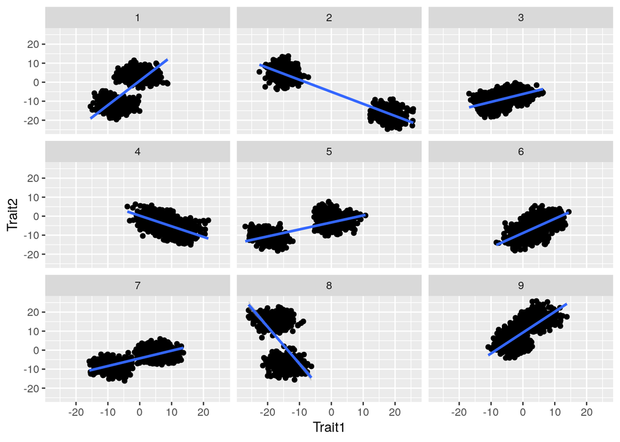

```r
balanced_df <- data.frame(Trait1 = numeric(0),
                       Trait2 = numeric(0),
                       Tree = numeric(0))
for(i in 1:n_trees){
  balanced_df <- rbind(balanced_df,
                    data.frame(Trait1 = fastBM(balanced),
                               Trait2 = fastBM(balanced),
                               Tree = i))
}
ggplot(balanced_df,aes(x = Trait1, y = Trait2)) +
  geom_point() +
  stat_smooth(method="lm") +
  facet_wrap(vars(Tree))
```

Now, we really only have two datapoints here (our two major phylogenetic groups), but we have created the illusion of having over 1000, and this leads to our spurious results. Note that if you looked within either of our two clusters we would be unlikely to find any real trend. This idea is similar to that of [Simpson’s Paradox](https://en.wikipedia.org/wiki/Simpson%27s_paradox), which you should also be wary of when aggregating data that might have underlying (non-phylogenetic) structure.

## Testing for Phylogenetic Signal

Often researchers will want to know if their trait has significant phylogenetic signal (for very fast-evolving traits evolutionary history may get “washed-out”, making correcting for it unnecessary - though some will argue you should use phylogenetically corrected methods no-matter what).

Let’s test for phylogenetic signal in the traits simulated on one of our first phylogenies:

```r
#Let's just look at the first tree
traits_tree1 <- subset(trait_df, trait_df$Tree == 1)
tree1 <- trees[[1]]

phylosig(tree1, traits_tree1$Trait1, method = "K", test = TRUE)
```

```
## [1] "x has no names; assuming x is in the same order as tree$tip.label"
```

```
##
## Phylogenetic signal K : 0.540961
## P-value (based on 1000 randomizations) : 0.001
```

```r
phylosig(tree1, traits_tree1$Trait1, method = "lambda", test = TRUE)
```

```
## [1] "x has no names; assuming x is in the same order as tree$tip.label"
```

```
##
## Phylogenetic signal lambda : 0.999934
## logL(lambda) : 1412.19
## LR(lambda=0) : 5462.42
## P-value (based on LR test) : 0
```

```r
phylosig(tree1, traits_tree1$Trait2, method = "K", test = TRUE)
```

```
## [1] "x has no names; assuming x is in the same order as tree$tip.label"
```

```
##
## Phylogenetic signal K : 0.182719
## P-value (based on 1000 randomizations) : 0.001
```

```r
phylosig(tree1, traits_tree1$Trait2, method = "lambda", test = TRUE)
```

```
## [1] "x has no names; assuming x is in the same order as tree$tip.label"
```

```
##
## Phylogenetic signal lambda : 0.999934
## logL(lambda) : 1394.62
## LR(lambda=0) : 4629.72
## P-value (based on LR test) : 0
```

Looks like there’s lots of phylogenetic signal in both of our simulated traits, as expected.

## Correcting for Phylogenetic Signal

There are lots of approaches and opinions on how to correct for phylogeny when, say, performing a regression. The oldest approach is Felsenstein’s independent contrasts - where he realized you could look at changes calculated along branches on the tree rather than at tip values and that these changes should be independent (there are some assumptions about the underlying model of trait evolution you need to make).

```r
traits_tree1$Species <- tree1$tip.label
tree1.data <- comparative.data(tree1, traits_tree1, names.col="Species", vcv.dim=2, warn.dropped=TRUE)
model.tree1 <- pgls(Trait1~Trait2, data=tree1.data)
summary(model.tree1)
```

```
##
## Call:
## pgls(formula = Trait1 ~ Trait2, data = tree1.data)
##
## Residuals:
##     Min      1Q  Median      3Q     Max
## -3.0197 -0.6482  0.0200  0.6801  3.3672
##
## Branch length transformations:
##
## kappa  [Fix]  : 1.000
## lambda [Fix]  : 1.000
## delta  [Fix]  : 1.000
##
## Coefficients:
##               Estimate Std. Error t value Pr(>|t|)
## (Intercept) -0.1376104  1.2054302 -0.1142   0.9091
## Trait2       0.0053366  0.0312241  0.1709   0.8643
##
## Residual standard error: 0.9982 on 998 degrees of freedom
## Multiple R-squared: 2.927e-05,   Adjusted R-squared: -0.0009727
## F-statistic: 0.02921 on 1 and 998 DF,  p-value: 0.8643
```

Observe that after correcting for phylogeny, there is no relationship between our two traits (which is correct). Note that we assume a Brownian Motion model of trait evolution when fitting our model (which was used to generate the original data so is correct, usually we won’t know the underlying model - see below).

If you have discrete traits (e.g., presence/absence or count data) check out the `phylolm` package.

## What Happens If You Use the Wrong Model?

The problem with parametric methods (in general), is that if you assume the wrong model you can get spurious results. This is also true when picking an evolutionary model for PGLS. The two most commonly used models are based on common random processes:  
- Brownian Motion, which is basically just random non-directional change  
- [Ornstein-Uhlenbeck](https://lukejharmon.github.io/pcm/chapter6_beyondbm/), assumes directional change towards some optimum (slighlty more complicated)

```r
trait_OU_df <- data.frame(Trait1 = fastBM(tree1, mu = 10),
                       Trait2 = fastBM(tree1, mu = 5))
trait_OU_df$Species <- tree1$tip.label
tree1.data <- comparative.data(tree1, trait_OU_df, names.col="Species", vcv.dim=2, warn.dropped=TRUE)
model.tree1 <- pgls(Trait1~Trait2, data=tree1.data)
summary(model.tree1)
```

```
##
## Call:
## pgls(formula = Trait1 ~ Trait2, data = tree1.data)
##
## Residuals:
##      Min       1Q   Median       3Q      Max
## -2.98699 -0.68323 -0.00859  0.67719  3.04569
##
## Branch length transformations:
##
## kappa  [Fix]  : 1.000
## lambda [Fix]  : 1.000
## delta  [Fix]  : 1.000
##
## Coefficients:
##               Estimate Std. Error t value Pr(>|t|)
## (Intercept) 35.8639893  1.3533879 26.4994   <2e-16 ***
## Trait2       0.0047676  0.0311461  0.1531   0.8784
## ---
## Signif. codes:  0 '***' 0.001 '**' 0.01 '*' 0.05 '.' 0.1 ' ' 1
##
## Residual standard error: 1.024 on 998 degrees of freedom
## Multiple R-squared: 2.348e-05,   Adjusted R-squared: -0.0009785
## F-statistic: 0.02343 on 1 and 998 DF,  p-value: 0.8784
```

There’s lots of [tutorials](https://lukejharmon.github.io/ilhabela/instruction/2015/07/03/PGLS/) for this type of stuff online. Most packages at least incorporate BM and OU type models.

I’ll note that [recently there has been an emphasis on models that take into account rate shifts in trait evolution across the tree](https://doi.org/10.1093/sysbio/syy031). That is, if the rate of trait evolution changes in different parts of your phylogeny (e.g., because of a change in mutation rate), it is possible to get spurious results unless you apply a model that accounts for this.

Finally, you can do a lot of [other things than just look for trait associations](https://www.zoology.ubc.ca/prog/diversitree/) with this sort of data. For example, you can try and [infer the phenotypes of now-extinct ancestral species](https://en.wikipedia.org/wiki/Ancestral_reconstruction), or [see if traits influence the rate of diversification of a lineage](https://academic.oup.com/sysbio/article/56/5/701/1694265).